# Demonstration of workflow

The methods below are described in our article

> Larsson, Held, et al. (2024) Reconstructing the regulatory programs underlying the phenotypic plasticity of neural cancers. Nature Communications 15, 9699 DOI 10.1038/s41467-024-53954-3

Here we demonstrate the scregclust workflow using the PBMC data from 10X Genomics (available [here](https://www.10xgenomics.com/resources/datasets/pbmc-from-a-healthy-donor-granulocytes-removed-through-cell-sorting-3-k-1-standard-2-0-0)). This is the same data used in an [introductory vignette](https://satijalab.org/seurat/articles/pbmc3k_tutorial) for the Seurat package. We use [Seurat](https://satijalab.org/seurat/) for pre-processing of the data.

```r
# Load required packages
library(Seurat)
library(scregclust)
```

# Download the data

We are focusing here on the filtered feature barcode matrix available as an HDF5 file from the website linked above. The data can be downloaded manually or using R.

```r
url <- paste0(
  "https://cf.10xgenomics.com/samples/cell-arc/2.0.0/",
  "pbmc_granulocyte_sorted_3k/",
  "pbmc_granulocyte_sorted_3k_filtered_feature_bc_matrix.h5"
)
data_path <- file.path(
  tempdir(), "pbmc_granulocyte_sorted_3k_filtered_feature_bc_matrix.h5"
)

download.file(url, data_path, cacheOK = FALSE, mode = "wb")
```

# Load the data in Seurat and preprocess

To perform preprocessing use Seurat to load the data. The file ships with two modalities, “Gene Expression” and “Peaks”. We only use the former.

```r
pbmc_data <- Read10X_h5(
  data_path,
  use.names = TRUE,
  unique.features = TRUE
)[["Gene Expression"]]
```

```
#> Genome matrix has multiple modalities, returning a list of matrices for this genome
```

We create a Seurat object and follow the Seurat vignette to subset the cells and features (genes).

```r
pbmc <- CreateSeuratObject(
  counts = pbmc_data, min.cells = 3, min.features = 200
)

pbmc[["percent.mt"]] <- PercentageFeatureSet(pbmc, pattern = "^MT.")
pbmc <- subset(pbmc, subset = percent.mt < 30 & nFeature_RNA < 6000)
```

[SCTransform](https://satijalab.org/seurat/articles/sctransform_vignette) is used for variance stabilization of the data and Pearson residuals for the 6000 most variable genes are extracted as matrix `z`.

```r
pbmc <- SCTransform(pbmc, variable.features.n = 6000)
```

[output not shown]

```r
z <- GetAssayData(pbmc, layer = "scale.data")
dim(z)
```

```
#> [1] 6000 2686
```

# Use scregclust for clustering target genes into modules

We then use `scregclust_format` which extracts gene symbols from the expression matrix and determines which genes are considered regulators. By default, transcription factors are used as regulators. Setting `mode` to `"kinase"` uses kinases instead of transcription factors. A list of the regulators used internally is returned by `get_regulator_list()`.

```r
out <- scregclust_format(z, mode = "TF")
```

The output of `scregclust_format` is a list with three elements.

1. `genesymbols` contains the rownames of `z`
2. `sample_assignment` is initialized to be a vector of `1`s of length `ncol(z)` and can be filled with a known sample grouping. Here, we do not use it and just keep it uniform across all cells.
3. `is_regulator` is an indicator vector (elements are 0 or 1) corresponding to the entries of `genesymbols` with 1 marking that the genesymbol is selected as a regulator according to the model of `scregclust_format` (`"TF"` or `"kinase"`) and 0 otherwise.

```r
genesymbols <- out$genesymbols
sample_assignment <- out$sample_assignment
is_regulator <- out$is_regulator
```

Run `scregclust` with number of initial modules set to 10 and test several penalties. The penalties provided to `penalization` are used during selection of regulators associated with each module. An increasing penalty implies the selection of fewer regulators. `noise_threshold` controls the minimum $R^2$ a gene has to achieve across modules. Otherwise the gene is marked as noise. The run can be reproduced with the command below. A pre-fitted model can be downloaded from [GitHub](https://github.com/scmethods/scregclust/raw/main/datasets/pbmc_scregclust.rds) for convenience.

```r
# set.seed(8374)
# fit <- scregclust(
#   z, genesymbols, is_regulator, penalization = seq(0.1, 0.5, 0.05),
#   n_modules = 10L, n_cycles = 50L, noise_threshold = 0.05
# )
# saveRDS(fit, file = "datasets/pbmc_scregclust.rds")

url <- paste0(
  "https://github.com/scmethods/scregclust/raw/main/datasets/",
  "pbmc_scregclust.rds"
)
fit_path <- file.path(tempdir(), "pbmc_scregclust.rds")
download.file(url, fit_path)
fit <- readRDS(fit_path)
```

# Analysis of results

Results can be visualized easily using built-in functions. Metrics for helping in choosing an optimal penalty can be plotted by calling `plot` on the object returned from `scregclust`.

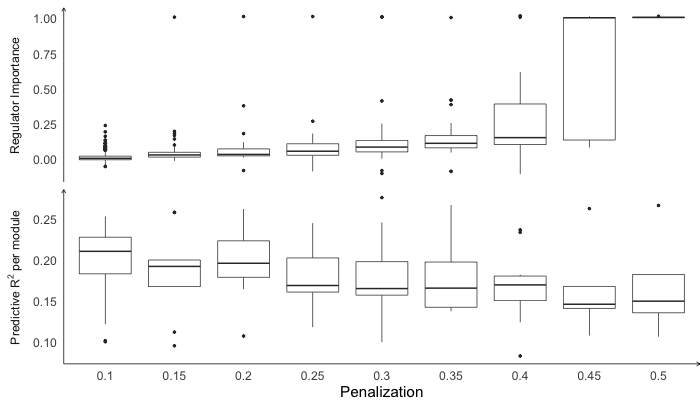

```r
plot(fit)
```

The results for each penalization parameter are placed in a list, `results`, attached to the `fit` object. So `fit$results[[1]]` contains the results of running `scregclust` with `penalization = 0.1`. For each penalization parameter, the algorithm might end up finding multiple optimal configurations. Each configuration describes target genes module assignments and which regulators are associated with which modules. The results for each such configuration are contained in the list `output`. This means that `fit$results[[1]]$output[[1]]` contains the results for the first final configuration. More than one may be available.

```r
sapply(fit$results, function(r) length(r$output))
```

```
#> [1] 2 1 1 1 2 2 2 1 1
```

In this example, at most two final configurations were found for each penalization parameters.

To plot the regulator network of the first configuration for `penalization = 0.1` the function `plot_regulator_network` can be used.

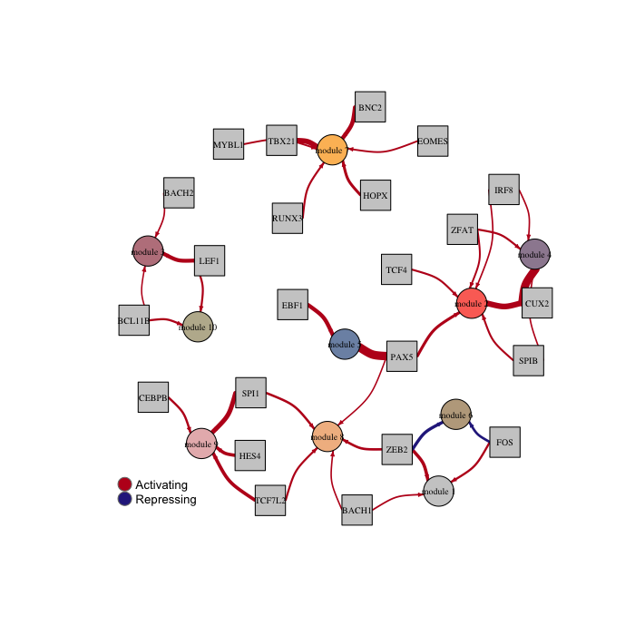

```r
plot_regulator_network(fit$results[[1]]$output[[1]])
```